# Analyzing the effect of ovarian hormones on women's body odor attractiveness using Bayesian hierarchical model

### Paul Kovacs

### Mei Mei

### Nicholas Pfau

1. Ovarian hormones (Estrogen and Progesterone)
2. Ovulation status (yes or no)
3. Odor attractiveness (judged by men)
- [x] 1 & 2: Well-studied in Biology and Medicine
- [x] 2 & 3: Tones of literatures on different mammals, including human
- [ ] 1 & 3: Evidence for voles and macaques -- what about human?

### Estradiol and Progesterone in a cycle

[figure not shown]

### What information (if any) is contained in women’s body odor?

1. First possibility: E + P -, same as most mammal.
   - A signal of ovulation.
     - “Is she ovulating right now?”
     - “If I have sex with her right now, is there’s a possibility that she will conceive?”
2. Second possibility: E + P null
   - Signals general reproductive condition.
     - “Is she pass puberty, pre menopause and of good health?”
     - ”Will she have ovulatory cycles in the near future during which she will be able to conceive?”

### Current dataset

1. Odor collection
   - Naturally cycling women (N = 47, Age 18-25) were asked to wear underarm pads overnight every five days over the course of 30 days (a total of 6 samples per woman)
   - Saliva samples on odor collection days
     - Assayed for estradiol and progesterone
   - Daily luteinizing hormone (LH) tests
     - Positive LH indicate ovulation within 24 hrs

```python
#Loading data
odor = pd.read_csv('/Users/meimei/womendaily+rating.csv')

len(odor[['raterid', 'SubId.0']].dropna()['SubId.0'].unique())
```

```
47
```

###### Current dataset

1. Rating sessions
   - Odor samples were rated across five rating sessions
     - Samples of 9-10 donors (54-60 samples) in each session
     - 10-17 raters in each session
   - Male raters (N = 66) were asked to sniff individual samples from glass jars.
     - Rate the odor for pleasantness, sexiness and intensity using 7-point Likert scales.

```python
odor[['blockid','raterid']].drop_duplicates().dropna().groupby('blockid')['raterid'].count()
```

```
blockid
1.0    10
2.0    12
3.0    14
4.0    13
5.0    17
Name: raterid, dtype: int64
```

### Centering and resacling variables

- Because each rater use the rating scale differntly, we recentered pleasentness, sexiness and intensity on each rater's own mean rating given

```python
odor1 = odor[odor['water'].isna()].dropna(subset=['raterid'])
odor2 = odor1[["SubId.0", "raterid", "Salivanumb", "Estradiol.ext", "Progest",
               "Pleasant","Intensity","Sexiness", "blockid"]]

#calculate rater centered ratings
means = odor2.groupby('raterid')['Pleasant','Sexiness','Intensity', 'raterid'].mean()
means.columns = ['Pleasant_mean','Sexiness_mean','Intensity_mean', 'raterid']

odor3 = odor2.set_index('raterid').join(means.set_index('raterid')).reset_index()
odor3["Pleasant_ratcen"] = odor3["Pleasant"]-odor3["Pleasant_mean"]
odor3["Intensity_ratcen"] = odor3["Intensity"]-odor3["Intensity_mean"]
odor3["Sexiness_ratcen"] = odor3["Sexiness"]-odor3["Sexiness_mean"]
```

### Centering and resacling variables

- Donor's hormone concentration is also centered on their own mean hormone levels and scaled with the standerd deviation of all donors

```python
#calculate donor centered hormones with SD of the all donors
means2 = odor2.groupby('SubId.0')['Estradiol.ext', 'Progest','SubId.0'].mean()
means2.columns = ['E_submean', 'P_submean','SubId.0']

odor4 = odor3.set_index('SubId.0').join(means2.set_index('SubId.0')).reset_index()
odor4['subcenzestrad'] = (odor4['Estradiol.ext']-odor4['E_submean'])/odor4['Estradiol.ext'].std()
odor4['subcenzprogest'] = (odor4['Progest']-odor4['P_submean'])/odor4['Progest'].std()
odor4['sexyplea_ratcen'] = (odor4["Pleasant_ratcen"] + odor4["Sexiness_ratcen"])/2
```

### Centering and resacling variables

- We combined pleasantness and sexiness to create an attractiveness composite, as they’re highly correlated

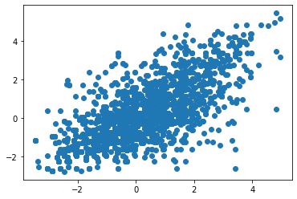

```python
plt.scatter(odordf['Pleasant_ratcen'], odordf['Sexiness_ratcen'])
plt.show()
```

```python
datsp = odor[['Pleasant_ratcen','Sexiness_ratcen']]
datsp.corr()
```

|  | Pleasant_ratcen | Sexiness_ratcen |
| --- | --- | --- |
| Pleasant_ratcen | 1.000000 | 0.730468 |
| Sexiness_ratcen | 0.730468 | 1.000000 |

### How much do raters agree with eachother?

- In order to see if the rater agree with eachother on the samples' rating, we conducted intraclass correlation on the raters from all five rating sessions.
- ICC of raters from rating session 2:

```python
icc2.set_index('Type')
```

| Type | Description | ICC | F | df1 | df2 | pval | CI95% |
| --- | --- | --- | --- | --- | --- | --- | --- |
| ICC1 | Single raters absolute | 0.231514 | 4.615115 | 51 | 572 | 2.134422e-20 | [0.15, 0.34] |
| ICC2 | Single random raters | 0.230548 | 4.526363 | 51 | 561 | 9.054014e-20 | [0.15, 0.34] |
| ICC3 | Single fixed raters | 0.227121 | 4.526363 | 51 | 561 | 9.054014e-20 | [0.15, 0.34] |
| ICC1k | Average raters absolute | 0.783321 | 4.615115 | 51 | 572 | 2.134422e-20 | [0.69, 0.86] |
| ICC2k | Average random raters | 0.782396 | 4.526363 | 51 | 561 | 9.054014e-20 | [0.68, 0.86] |
| ICC3k | Average fixed raters | 0.779072 | 4.526363 | 51 | 561 | 9.054014e-20 | [0.68, 0.86] |